# Acquiring Static Data in R

Bytes & Bridges - Data Engineering

Ricardo Mendes

2024-04-16

# **Acquiring Static Data**

## **Excel File**

Excel files are widely used in companies and can be an easy to create file when you need to import structured data.

```r
if(!require(xlsx)) install.packages("xlsx", INSTALL_opts=c("--no-multiarch"))
library("xlsx")

car_list <- read.xlsx("Car List.xlsx", sheetIndex=1)
head(car_list)
```

|  | Vehicle | Year | P.S | New | Used | Car.Prize |
| --- | --- | --- | --- | --- | --- | --- |
| 1 | AC Cars 427 S/C ‘66 | 1966 | S | NA | 239303 | NA |
| 2 | Acura CL 3.2 Type-S ‘01 | 2001 | S | NA | NA | NA |
| 3 | Acura CL 3.2 Type-S ‘03 | 2003 | S | NA | 28769 | NA |
| 4 | Acura DN-X Concept ‘02 | 2002 | S | NA | NA | IC License Bronze |
| 5 | Acura HSC Concept ‘04 | 2004 | S | NA | NA | NA |
| 6 | Acura INTEGRA TYPE R ‘01 | 2001 | S | NA | NA | NA |

```r
NA
```

## **CSV File**

```r
# Read a CSV file and show the first 5 rows
countries <- read.csv("Countries.csv", sep = ";")
head(countries)
```

|  | country | latitude | longitude | name |
| --- | --- | --- | --- | --- |
| 1 | AD | 42.54624 | 1.601554 | Andorra |
| 2 | AE | 23.42408 | 53.847818 | United Arab Emirates |
| 3 | AF | 33.93911 | 67.709953 | Afghanistan |
| 4 | AG | 17.06082 | -61.796428 | Antigua and Barbuda |
| 5 | AI | 18.22055 | -63.068615 | Anguilla |
| 6 | AL | 41.15333 | 20.168331 | Albania |

```r
NA
```

## **JSON File**

Another type of file that is very common is the JSON file. Here is how you can read specific values within it:

```r
# Read the JSON file
user_config <- jsonlite::fromJSON("UserConfig.json")

# Print the values within the configuration
cat("Username:", user_config$username, "\n")
```

```
Username: test123
```

```r
cat("Language:", user_config$language, "\n")
```

```
Language: en-us
```

```r
cat("Fullscreen:", user_config$fullscreen, "\n")
```

```
Fullscreen: FALSE
```

## **Image File**

It is often necessary to read image files. They can be used as icons, logos, or for any other purpose. Check below how to do that:

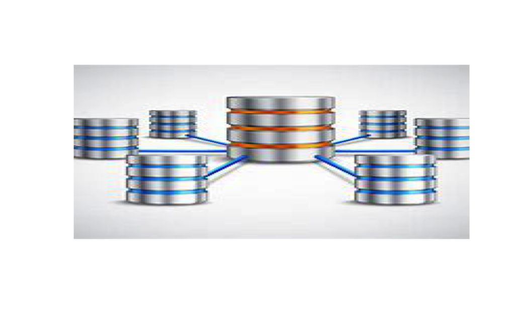

```r
if(!require(jpeg)) install.packages("jpeg")
library("jpeg")

# Read the image file
image_path = "Image.jpeg"
image <- readJPEG(image_path, native = TRUE)

# Open the file in a separate window:
plot(0:1, 0:1, type = "n", ann = FALSE, axes=FALSE)

# Show the image inline
rasterImage(image, 0, 0, 1, 1)
```

## **Web Pages**

In some cases, you might want to read information directly from a web page, instead of selecting it, creating a file, and then reading the file. The code below shows one of the many ways in which you can accomplish that by reading the list of the busiest airports in 2022:

```r
# Load necessary libraries
library(rvest)  # For web scraping
library(dplyr)  # For data manipulation

# URL of the Wikipedia page
url <- "https://en.wikipedia.org/wiki/List_of_busiest_airports_by_passenger_traffic"

# Read the HTML content from the URL
webpage <- read_html(url)

# Extract the table containing the airport data (second table on the page)
airport_table <- html_nodes(webpage, "table.wikitable.sortable")[2]

# Convert the table to a dataframe
df_airports <- airport_table %>%
  html_table(fill = TRUE) %>%
  as.data.frame()

# Rename columns for clarity
colnames(df_airports) <- c("Rank", "Airport", "Location", "Country", "Code", "Total_Passengers", "Rank_Change", "Percent_Change")

# Select the most relevant columns
df_airports <- df_airports %>%
  select(Rank, Airport, Location, Total_Passengers)

# Display the resulting dataframe
df_airports
```

| Rank | Airport | Location | Total_Passengers |
| --- | --- | --- | --- |
| 1 | Hartsfield–Jackson Atlanta International Airport | Atlanta, Georgia | 93,699,630 |
| 2 | Dallas Fort Worth International Airport | Dallas–Fort Worth, Texas | 73,362,946 |
| 3 | Denver International Airport | Denver, Colorado | 69,286,461 |
| 4 | O'Hare International Airport | Chicago, Illinois | 68,340,619 |
| 5 | Dubai International Airport | Garhoud, Dubai, Dubai | 66,069,981 |
| 6 | Los Angeles International Airport | Los Angeles, California | 65,924,298 |
| 7 | Istanbul Airport | Arnavutköy, Istanbul | 64,289,107 |
| 8 | Heathrow Airport | Hillingdon, London | 61,614,508 |
| 9 | Indira Gandhi International Airport | Palam, Delhi | 59,490,074 |
| 10 | Charles de Gaulle Airport | Roissy-en-France, Île-de-France | 57,474,033 |

[output cut: 40 more lines]